# Explatory Analysis

2022-05-20

# Introduction

Our group wishes to analyze patterns in nutrition, physical activity, and obesity in the United States, in order to spread awareness of the decline in mental and physical health caused by the pandemic. Knowing that we are not alone affected by this, we can work together to regain the physical activity of our communities and ultimately push for better health across the world. This data set is provided by the CDC website for chronic disease prevention and health promotion, division of nutrition, physical activity, and obesity. It is collected by the Behavioral Risk Factor Surveillance System. The data addresses adult diets, physical activity and weight status.

# Summary paragraph

The data set has questions pertaining to physical health, and tracks the percentage of people that fall into the question asked. The topic that was often under evaluation on this data set was:

```
## [1] "Physical Activity - Behavior"
```

Another value of interest was the way the data was collected. Each observation had a column for how the data was gathered, but the only unique way that the data was gathered was by:

```
## [1] "Behavioral Risk Factor Surveillance System"
```

The total number of studies collected by this data set was:

```
## [1] 80929
```

The most common stratification group targeted by questions was:

```
## [1] "Race/Ethnicity"
```

We were interested in the study that had the largest sample size, and the information on it was that:

```
## [1] "Year: 2016"
```

```
## [1] "Location: Florida"
```

```
## [1] "Topic: Physical Activity - Behavior"
```

```
## [1] "Question: Percent of adults who engage in no leisure-time physical activity"
```

```
## [1] "Sample_Size: 36868"
```

# Table of aggregated data

This table shows the average percentage of US citizens that fall into under the category prompted by the question. This table shows a very broad view of the statistics regarding physical health over the US as a whole.

```
## # A tibble: 9 x 2
##   Question                                                      `% of US citiz~`
##   <chr>                                                                    <dbl>
## 1 Percent of adults aged 18 years and older who have an overwe~             34.6
## 2 Percent of adults aged 18 years and older who have obesity                30.1
## 3 Percent of adults who achieve at least 150 minutes a week of~             49.8
## 4 Percent of adults who achieve at least 150 minutes a week of~             20.4
## 5 Percent of adults who achieve at least 300 minutes a week of~             31.1
## 6 Percent of adults who engage in muscle-strengthening activit~             30.7
## 7 Percent of adults who engage in no leisure-time physical act~             26.0
## 8 Percent of adults who report consuming fruit less than one t~             39.1
## 9 Percent of adults who report consuming vegetables less than ~             20.9
```

# Chart 1

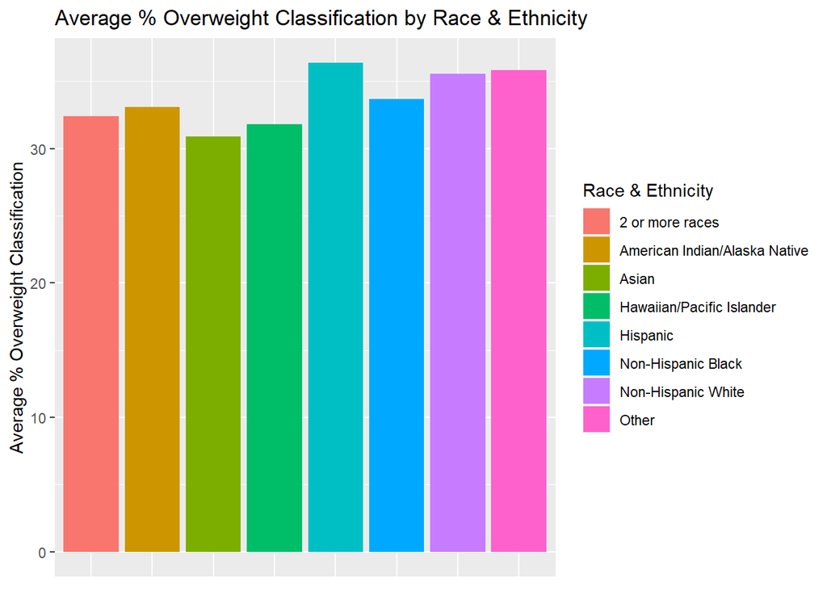

# Chart 2

This chart shows the amount of surveys done per year regarding health and nutrition. However, these counts are only for studies done for the US as a whole, excluding state specific studies for the count.

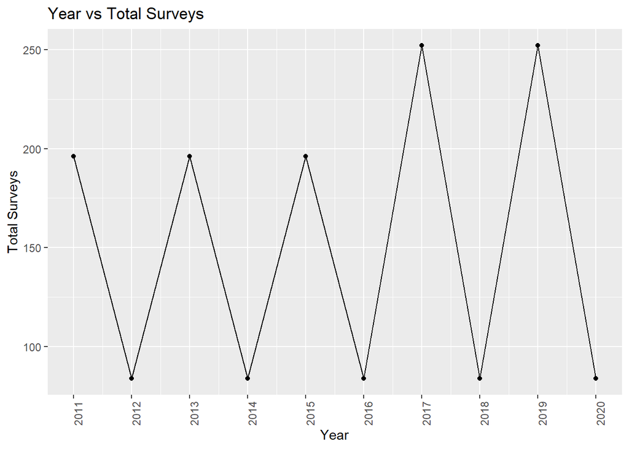

# Chart 3

This map gives a good visualization of the percentage of adults that are classified as obese in America. One notable observation is that Colorado seems to be absolved of obesity due to how white it is on the legend, but in reality the lowest level of obesity is still close to 24% of the adult population.

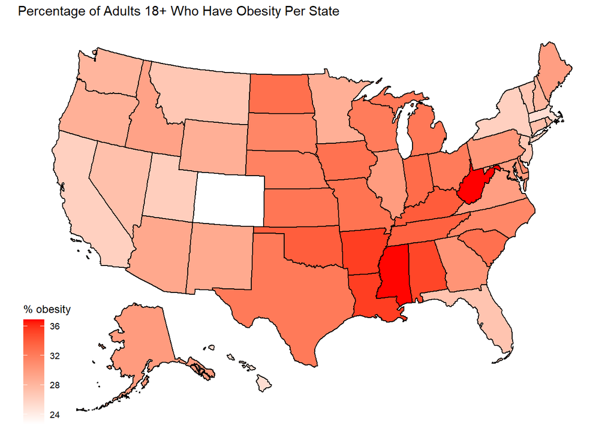